# UNIT08A：集群分析與尺度縮減

中山大學管理學院 卓雍然

2022-04-29 11:36:18

```r
pacman::p_load(dplyr, ggplot2, readr, FactoMineR, factoextra, dendextend)
```

### 【A】批發商資料集

```r
W = read.csv('data/wholesales.csv')
W$Channel = factor( paste0("Ch",W$Channel) ) # Ch1、Ch2
W$Region = factor( paste0("Reg",W$Region) )  # Reg1、2、3
W[3:8] = lapply(W[3:8], log, base=10)        # 取log方便看*數量or價格等
summary(W)
```

```
 Channel    Region        Fresh            Milk         Grocery
 Ch1:298   Reg1: 77   Min.   :0.477   Min.   :1.74   Min.   :0.477
 Ch2:142   Reg2: 47   1st Qu.:3.495   1st Qu.:3.19   1st Qu.:3.333
           Reg3:316   Median :3.930   Median :3.56   Median :3.677
                      Mean   :3.792   Mean   :3.53   Mean   :3.666
                      3rd Qu.:4.229   3rd Qu.:3.86   3rd Qu.:4.028
                      Max.   :5.050   Max.   :4.87   Max.   :4.968
     Frozen     Detergents_Paper   Delicassen
 Min.   :1.40   Min.   :0.477    Min.   :0.477
 1st Qu.:2.87   1st Qu.:2.409    1st Qu.:2.611
 Median :3.18   Median :2.912    Median :2.985
 Mean   :3.17   Mean   :2.947    Mean   :2.895
 3rd Qu.:3.55   3rd Qu.:3.594    3rd Qu.:3.260
 Max.   :4.78   Max.   :4.611    Max.   :4.681
```

```r
# 7-11&全家 / 北&中&南

# 集群分析(分群)與尺度縮減(降維)
```

### 【B】層級式集群分析(Clustering Analysis)

集群分析：將分析對象依其 **相似性** 分群

- 分析對象：各零售店
- 分群(區隔)變數：各類商品的購買數量

💡 層級式集群分析的步驟：  
■ `scale()` : 標準化 Standardization  
■ `dist()` : 距離矩陣  
■ `hclust()` : 層級式集群分析  
■ `plot()` : 畫出樹狀圖  
■ `rect.hclust()` : 依據dendrogram(樹狀圖)做切割  
■ `cutree()` : 產生分群向量

為了方便解釋，我們先使用兩個**分群變數**做**層級式集群分析**

```r
hc = W[,3:4] %>% scale %>% dist %>% hclust # 層級式集群分析

table(W$Channel,W$Region) # 7-11&全家 / 北&中&南
```

```
      Reg1 Reg2 Reg3
  Ch1   59   28  211
  Ch2   18   19  105
```

**樹狀圖的判讀與切割**

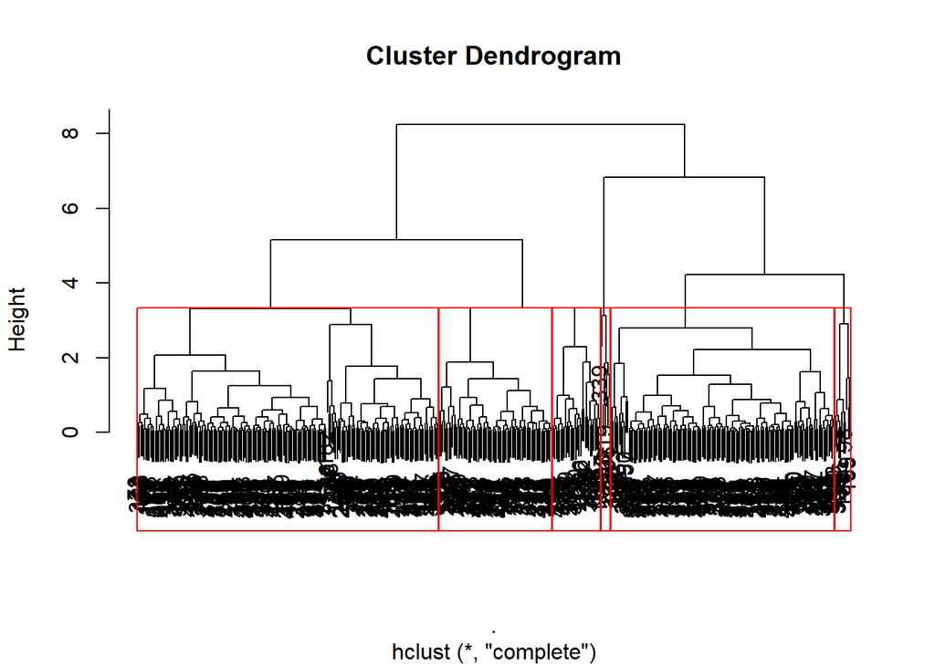

```r
plot(hc)
k=6;rect.hclust(hc, k=k, border="red")
```

```r
# 依據dendrogram(樹狀圖)做切割
```

**產生分群向量**

```r
W$group = cutree(hc, k=8) %>% factor  # 產生分群向量
W$group
```

```
  [1] 1 2 2 3 1 2 1 2 4 2 4 3 1 1 1 3 5 2 1 1 1 3 3 2 1 1 3 3 2 1 1 4 3 1 4 4 1
 [38] 1 2 3 1 1 2 5 2 2 2 2 1 2 3 4 1 5 3 4 2 2 3 2 1 2 2 1 3 5 6 1 4 1 3 3 4 1
 [75] 2 3 4 1 3 4 3 5 2 3 1 2 2 1 3 1 3 1 2 1 2 6 6 7 7 1 2 5 4 1 3 3 4 1 5 5 3
[112] 1 1 3 3 3 1 1 3 1 3 4 3 1 3 1 3 1 5 3 1 3 3 3 3 3 2 2 1 4 1 1 1 3 1 1 3 1
[149] 3 3 3 4 3 2 7 2 4 3 4 5 4 3 3 2 2 1 4 4 3 3 5 5 4 5 7 4 1 2 2 4 1 2 5 2 7
[186] 2 3 4 2 5 1 3 3 5 3 1 1 4 1 1 2 2 1 7 3 5 3 4 4 2 3 2 3 4 4 2 2 3 6 3 3 2
[223] 3 4 3 1 1 4 3 1 1 2 3 4 1 4 3 1 3 1 1 3 3 1 2 4 1 3 1 1 4 2 3 1 2 3 1 3 1
[260] 1 2 3 3 3 5 2 5 3 2 3 3 4 5 1 4 4 1 3 1 1 4 2 1 1 1 3 3 3 3 3 4 4 4 2 3 3
[297] 3 1 2 7 1 2 4 4 5 5 2 3 3 5 3 1 4 3 3 5 3 4 1 2 4 3 3 3 1 1 3 7 3 3 3 1 1
[334] 2 3 1 3 3 8 3 4 4 5 4 3 4 4 1 4 2 3 5 7 5 2 7 3 6 5 4 1 3 3 3 3 4 1 3 3 3
[371] 1 3 4 1 3 3 2 1 4 4 3 1 1 3 2 3 4 3 3 3 3 4 4 1 3 3 2 3 3 3 3 1 1 1 1 3 1
[408] 2 1 1 3 4 5 4 3 2 2 4 5 1 4 1 3 1 1 1 1 1 4 3 4 2 3 4 1 1 3 1 3 4
Levels: 1 2 3 4 5 6 7 8
```

**將分析對象畫在分群變數空間上面**

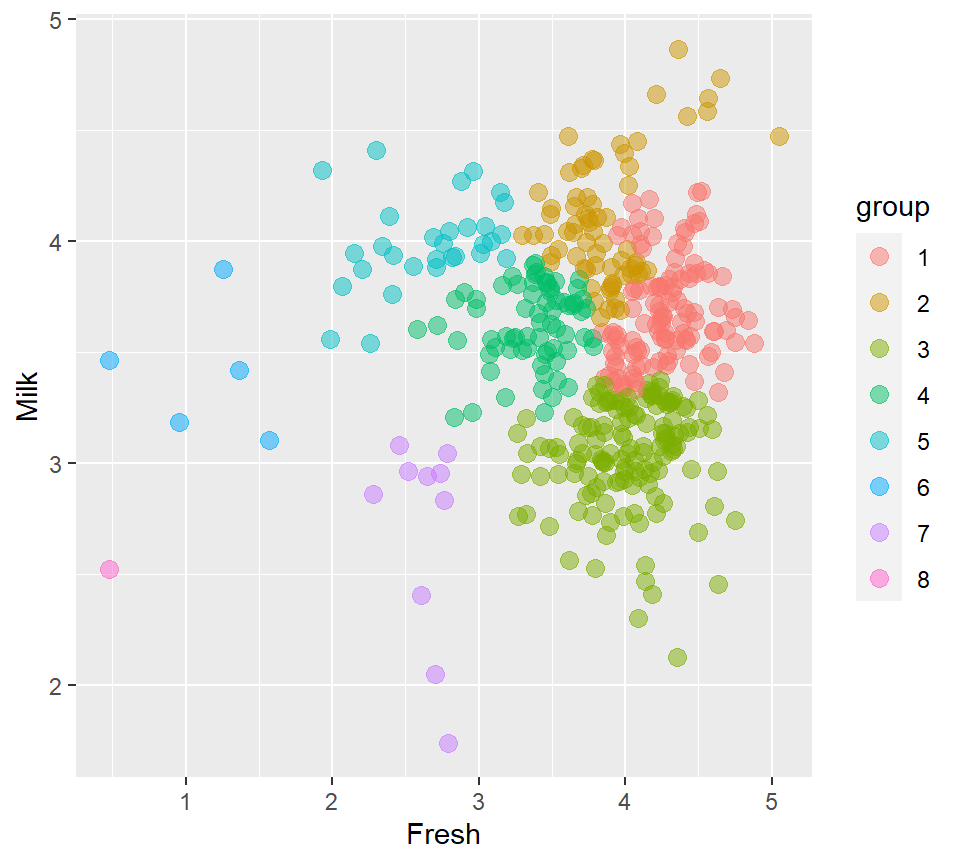

```r
ggplot(W, aes(x=Fresh, y=Milk, col=group)) +  # 生鮮VS牛奶
  geom_point(size=3, alpha=0.5)
```

### 【C】使用五個分群變數做分群

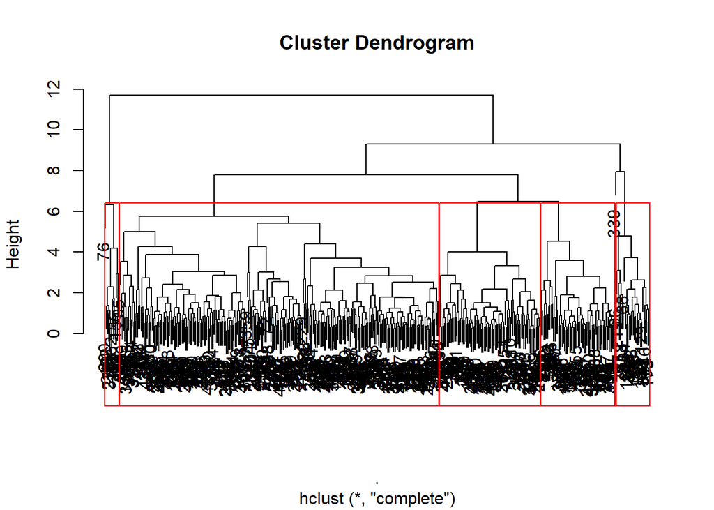

```r
hc = W[,3:7] %>% scale %>% dist %>% hclust   # 標準化(每個變數的(尺度)影響變一樣)-距離-分群
plot(hc)                                     # EX: 購買次數 & 購買金額
k = 6; rect.hclust(hc, k, border="red")      # hclust的dendextend不會告訴你怎麼切，要自己框群
```

```r
W$group = cutree(hc, k) %>% factor
```

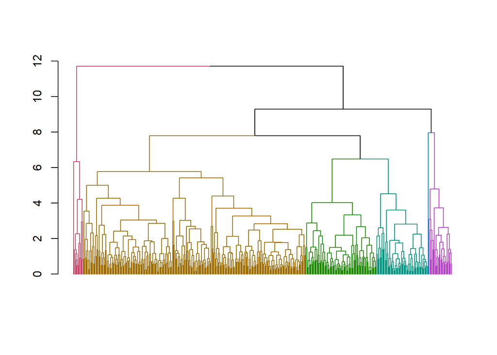

```r
hc %>% as.dendrogram %>% color_branches(k) %>% color_labels(k,col='white') %>% plot
```

```r
#as.dendrogram:提供處理樹狀結構的通用函數。
#替代層次聚類和分類/回歸樹中的類似功能，
#以便所有這些都可以使用相同的引擎來繪製或切割樹

#color_branches(k):根據子集群為樹的分支著色
#color_labels(k,col='white')根據子集群為dend的標籤著色
```

### 【D】尺度縮減(降維，Dimension Reduction)

- 為什麼要降維？ 資料太多、雜
- 降維的原理？ 投影到低維度，去掉不重要的東西
- 降維的好處？ 留重要的東西、訊練速度變快
- 降維的壞處？ 訊息損失

**降維的方法(工具)：** + 主成分分析：Principle Component Analysis - `PCA()` + 多元尺度分析：Multi-Dimensional Scaling - `cmdscale()`

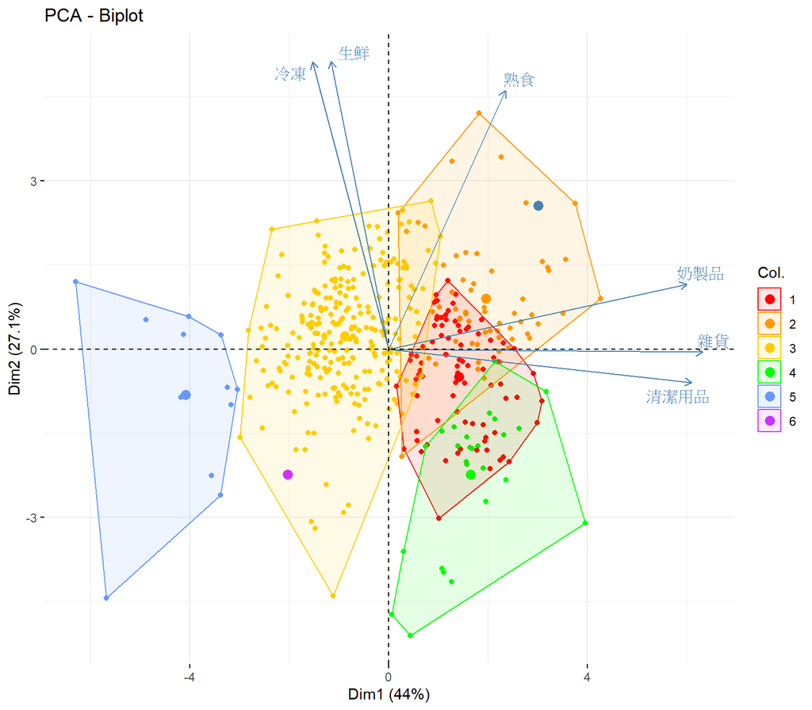

```r
names(W)[3:8] = c('生鮮','奶製品','雜貨','冷凍','清潔用品','熟食')

W[,3:8] %>% PCA(graph=FALSE) %>% fviz_pca_biplot(
  col.ind=W$group,
  label="var", pointshape=19, mean.point=T,
  addEllipses=T, ellipse.level=0.7,
  ellipse.type = "convex", palette="ucscgb",
  repel=T
  )
```

```r
# 使用來自factoextra包的以下功能：
# fviz_pca_ind() : 個人圖
# fviz_pca_var() : 變量圖
# fviz_pca_biplot()（或fviz_pca()）：個體和變量的Biplot

# http://www.sthda.com/english/wiki/fviz-pca-quick-principal-component-analysis-data-visualization-r-software-and-data-mining

# repel=T，避免文字互相重疊
```

💡 學習重點：  
■ 集群分析的基本觀念  
■ 距離矩陣：Distance Matrix  
■ 層級式集群分析：Hierarchical Cluster Analysis  
■ 樹狀圖(Dendrogram)的判讀  
■ 依據樹狀圖決定要分多少群  
■ 集群分析與尺度縮減的綜合應用  
■ 現代化的資料視覺化工具套件